# NHL Games

S&DS 361

2024-02-27

# Introduction

We previously used linear regression develop team ratings and predict game scores for NBA games. Linear regression is a reasonable model because NBA game scores appear to be fairly normally distributed, and the linear regression assumptions hold.

For sports like hockey and soccer, however, assumptions for linear regression fail. Scoring in those sports more closely follows a Poisson distribution. If linear regression is used the errors are not normally distributed. Also, since scoring is low, one could imagine scenarios in which the predicted game score could be negative. For these reason, we explore alternative regression models, starting with Poisson regression.

# Data Preparation

We start by creating data frames `db` for basketball and `dh` for hockey.

```r
d = readRDS('data/games.rds')

## Basketball
nba = d %>%
  filter(lg == 'nba',
         season %in% 1990:2022,
         season.type == 'reg') %>%
  select(date, away, home,
         ascore, hscore, season, gid)
head(d)
```

```
##         date away home ascore hscore  lg season season.type
## 1 2022-10-18  LAL  GSW    109    123 nba   2023         reg
## 2 2022-10-18  PHI  BOS    117    126 nba   2023         reg
## 3 2022-10-19  NOP  BKN    130    108 nba   2023         reg
## 4 2022-10-19  WAS  IND    114    107 nba   2023         reg
## 5 2022-10-19  ORL  DET    109    113 nba   2023         reg
## 6 2022-10-19  HOU  ATL    107    117 nba   2023         reg
##                   venue attendance      gid                   gkey  espn.gid
## 1          Chase Center      18064 22200002 nba.2022-10-18.LALvGSW 401468017
## 2             TD Garden      19156 22200001 nba.2022-10-18.PHIvBOS 401468016
## 3       Barclays Center      18003 22200006 nba.2022-10-19.NOPvBKN 401468021
## 4 Gainbridge Fieldhouse      15027 22200004 nba.2022-10-19.WASvIND 401468019
## 5  Little Caesars Arena      20190 22200003 nba.2022-10-19.ORLvDET 401468018
## 6      State Farm Arena      17878 22200005 nba.2022-10-19.HOUvATL 401468020
```

```r
da = nba %>% select(date, away, ascore, home, hscore, season, gid) %>% mutate(ha = 'away')
dh = nba %>% select(date, home, hscore, away, ascore, season, gid) %>% mutate(ha = 'home')
colnames(da) = c('date', 'team', 'score',  'opp', 'opp.score', 'season', 'gid', 'ha')
colnames(dh) = c('date', 'team', 'score',  'opp', 'opp.score', 'season', 'gid', 'ha')
db = bind_rows(da, dh) %>%
  arrange(date, gid)
head(db)
```

```
##         date team score opp opp.score season      gid   ha
## 1 1989-11-03  HOU    88 LAC       102   1990 28900001 away
## 2 1989-11-03  LAC   102 HOU        88   1990 28900001 home
## 3 1989-11-03  IND   126 ATL       103   1990 28900002 away
## 4 1989-11-03  ATL   103 IND       126   1990 28900002 home
## 5 1989-11-03  GOS   106 PHX       136   1990 28900003 away
## 6 1989-11-03  PHX   136 GOS       106   1990 28900003 home
```

```r
## Hockey
nhl = d %>%
  filter(lg == 'nhl',
         season %in% 2012:2022,
         season.type == 'reg') %>%
  select(date, away, home,
         ascore, hscore, season, gid)
head(nhl)
```

```
##         date away home ascore hscore season        gid
## 1 2021-10-12  PIT  TBL      6      2   2022 2021020001
## 2 2021-10-13  SEA  VGK      3      4   2022 2021020002
## 3 2021-10-13  MTL  TOR      1      2   2022 2021020003
## 4 2021-10-13  NYR  WSH      1      5   2022 2021020004
## 5 2021-10-14  WPG  ANA      1      4   2022 2021020015
## 6 2021-10-14  CHI  COL      2      4   2022 2021020005
```

```r
da = nhl %>% select(date, away, ascore, home, hscore, season, gid) %>% mutate(ha = 'away')
dh = nhl %>% select(date, home, hscore, away, ascore, season, gid) %>% mutate(ha = 'home')
colnames(da) = c('date', 'team', 'score',  'opp', 'opp.score', 'season', 'gid', 'ha')
colnames(dh) = c('date', 'team', 'score',  'opp', 'opp.score', 'season', 'gid', 'ha')
dh = bind_rows(da, dh) %>%
  arrange(date, gid)
head(dh)
```

```
##         date team score opp opp.score season        gid   ha
## 1 2011-10-06  BUF     2 BOS         1   2012 2011020001 away
## 2 2011-10-06  BOS     1 BUF         2   2012 2011020001 home
## 3 2011-10-06  MTL     0 TOR         2   2012 2011020002 away
## 4 2011-10-06  TOR     2 MTL         0   2012 2011020002 home
## 5 2011-10-07  PIT     4 VAN         3   2012 2011020003 away
## 6 2011-10-07  VAN     3 PIT         4   2012 2011020003 home
```

# Data Exploration

## NBA scores

Note that basketball scores appear fairly normally distributed

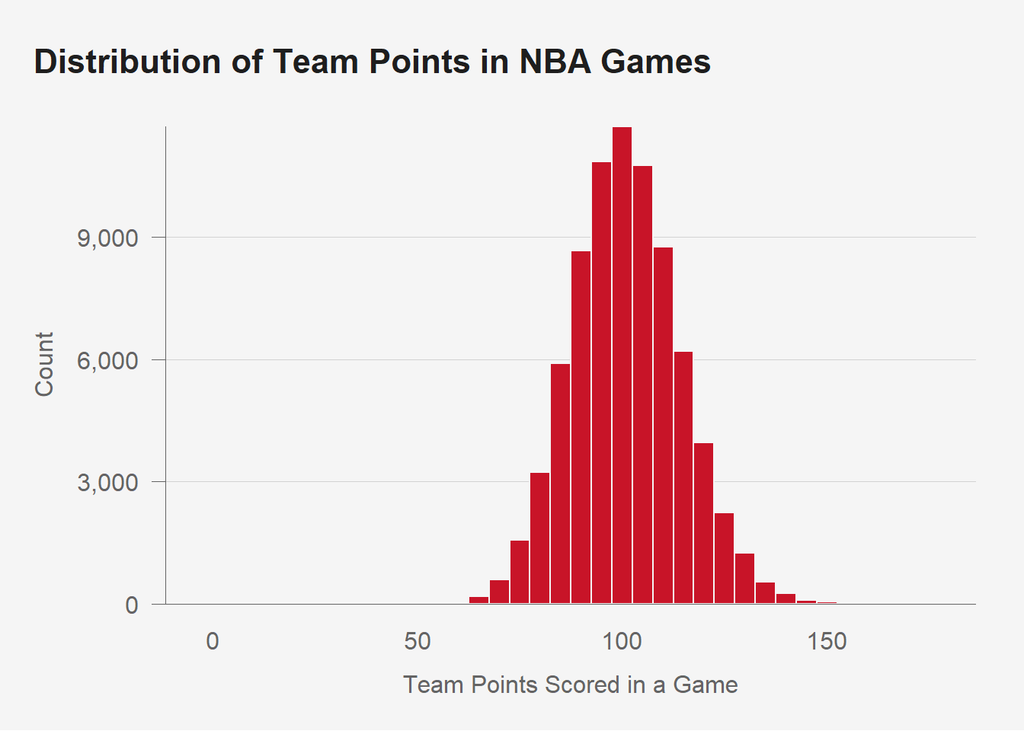

```r
title = 'Distribution of Team Points in NBA Games'
g  = ggplot(db,
            aes(x = score))+
  geom_histogram(fill = pubred,
                 color = pubbackgray,
                 binwidth = 5) +
  labs(title = title,
       x = 'Team Points Scored in a Game', ## Required.
       y = 'Count')

g %>%
  pub(type = 'hist')
```

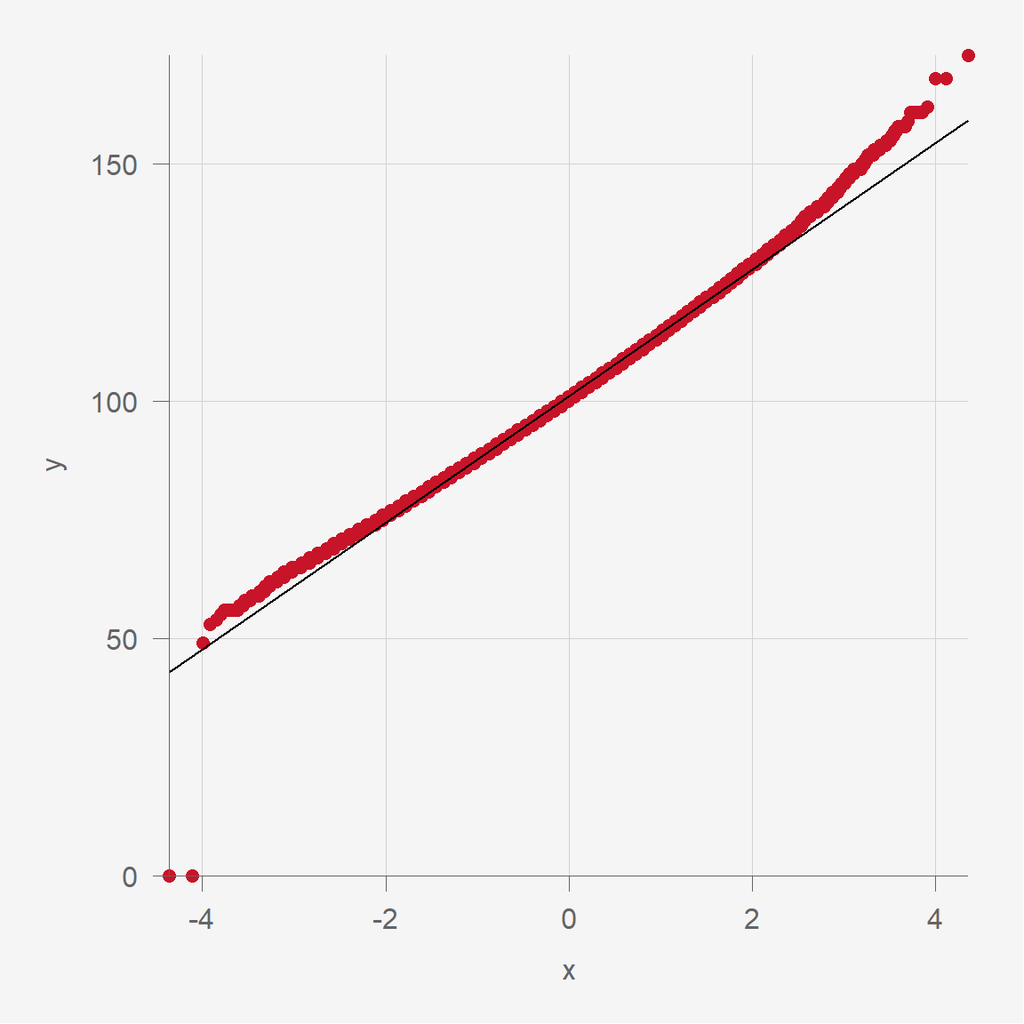

```r
g  = ggplot(db,
            aes(sample = score))+
  geom_qq(color = pubred) +
  geom_qq_line()

g %>%
  pub(type = 'scatter')
```

What we actually need is that scores are normally distributed *for a given set of predictors*. Fortunately, when we used a linear regression model to predict game scores, residuals were normally distributed.

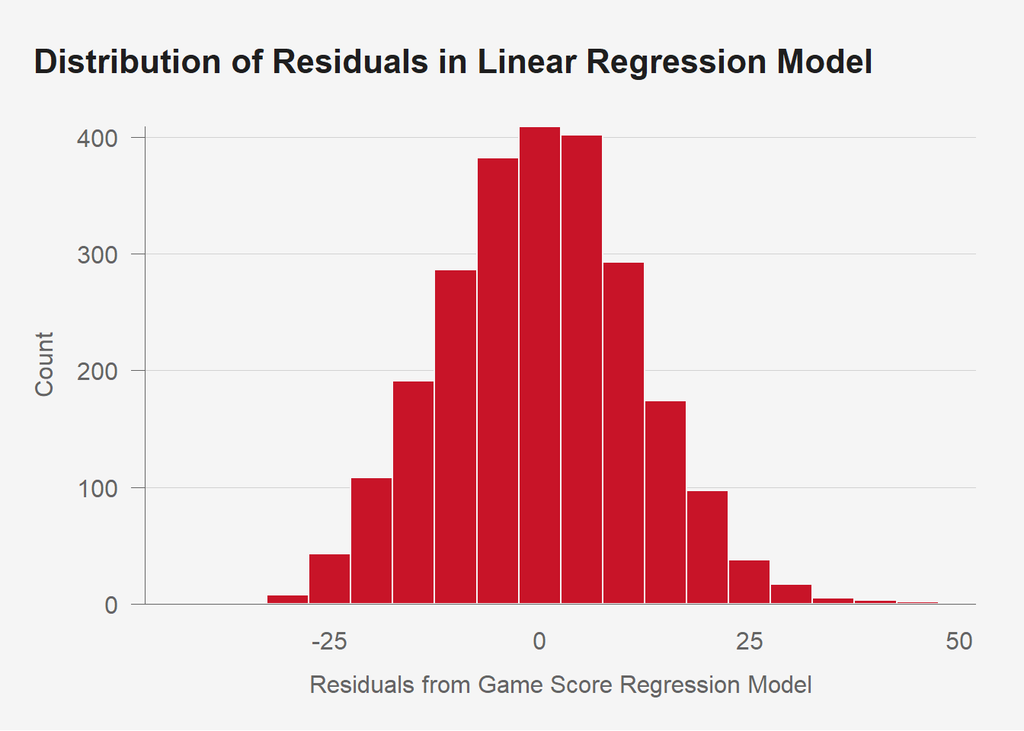

```r
dm = db %>% filter(season == 2022)
lm1 = lm(score ~ 1 + ha + team + opp,
         data = dm)

dm$pred = predict(lm1)
dm$res  = dm$score - dm$pred
title = 'Distribution of Residuals in Linear Regression Model'
g  = ggplot(dm,
            aes(x = res))+
  geom_histogram(fill = pubred,
                 color = pubbackgray,
                 binwidth = 5) +
  labs(title = title,
       x = 'Residuals from Game Score Regression Model', ## Required.
       y = 'Count')

g %>%
  pub(type = 'hist')
```

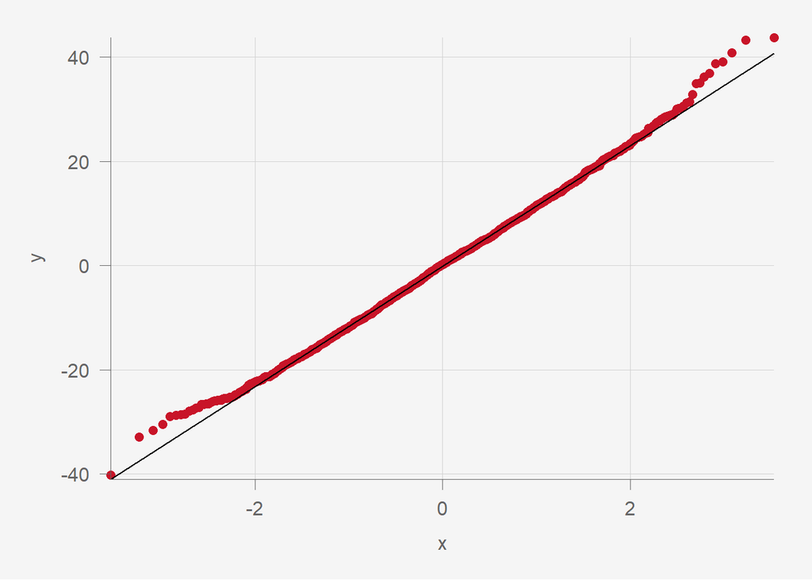

```r
g  = ggplot(dm,
            aes(sample = res))+
  geom_qq(color = pubred) +
  geom_qq_line()

g %>%
  pub(type = 'scatter')
```

## NHL scores

The same is not true for NHL scores. This does not look like a normal distribution:

[figure not shown]

```r
title = 'Distribution of Team Goals Scored in NHL Games'
g  = ggplot(dh,
            aes(x = score))+
  geom_histogram(fill = pubred,
                 color = pubbackgray,
                 binwidth = 1) +
  labs(title = title,
       x = 'Residuals from Game Score Regression Model', ## Required.
       y = 'Count')

g %>%
  pub(type = 'hist')
```

That however does look like a Poisson distribution. Also note that the mean and the variance are approximately equal.

```r
mean(dh$score)
```

```
## [1] 2.867495
```

```r
var(dh$score)
```

```
## [1] 2.777227
```

If we plot the PMF of a Poisson distribution with $lambda$ equal to that same mean 2.8674951 on top of a histogram of our data, we see they match up pretty well.

```r
df = data.frame(x = 0:12,
                y = dpois(0:12,
                          lambda = mean(dh$score)))
df
```

```
##     x            y
## 1   0 5.684113e-02
## 2   1 1.629917e-01
## 3   2 2.336889e-01
## 4   3 2.233673e-01
## 5   4 1.601261e-01
## 6   5 9.183217e-02
## 7   6 4.388805e-02
## 8   7 1.797840e-02
## 9   8 6.444120e-03
## 10  9 2.053165e-03
## 11 10 5.887440e-04
## 12 11 1.534746e-04
## 13 12 3.667397e-05
```

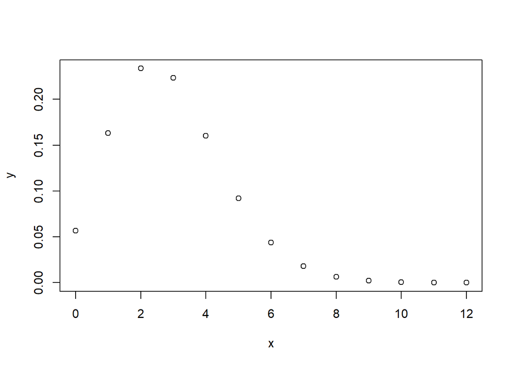

```r
plot(df)
```

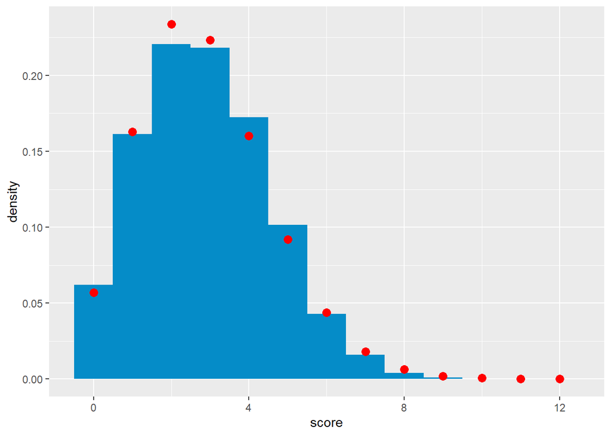

```r
# ggplot(dh, aes(x=score, y=..density..))+
#   geom_histogram(binwidth=1)+
#   geom_point(data=df, aes(x=x, y=y), color='red', size=3)

ggplot(dh,
       aes(x = score,
           y = after_stat(density)))+
  geom_histogram(binwidth = 1)+
  geom_point(data = df,
             aes(x = x,
                 y = y),
             color = 'red',
             size = 3)
```

```r
ds = dh %>%
  group_by(team, season) %>%
  summarise(avg.score = mean(score))
head(ds)
```

```
## # A tibble: 6 × 3
## # Groups:   team [1]
##   team  season avg.score
##   <chr> <chr>      <dbl>
## 1 ANA   2012        2.49
## 2 ANA   2013        2.92
## 3 ANA   2014        3.24
## 4 ANA   2015        2.88
## 5 ANA   2016        2.66
## 6 ANA   2017        2.72
```

```r
dh = dh %>%
  mutate(prev.season = as.character(as.numeric(season) - 1)) %>%
  left_join(ds,
            by=c('team',
                 'prev.season' = 'season')) %>%
  rename(avg.score.prev = avg.score) %>%
  filter(!is.na(avg.score.prev))
head(dh)
```

```
##         date team score opp opp.score season        gid   ha prev.season
## 1 2013-01-19  PIT     3 BUF         1   2013 2012020001 away        2012
## 2 2013-01-19  BUF     1 PIT         3   2013 2012020001 home        2012
## 3 2013-01-19  OTT     4 WPG         1   2013 2012020002 away        2012
## 4 2013-01-19  WPG     1 OTT         4   2013 2012020002 home        2012
## 5 2013-01-19  CHI     5 LAK         2   2013 2012020003 away        2012
## 6 2013-01-19  LAK     2 CHI         5   2013 2012020003 home        2012
##   avg.score.prev
## 1       3.439024
## 2       2.939024
## 3       3.036585
## 4       2.743902
## 5       3.024390
## 6       2.365854
```

SEA is a new team that didn’t play in 2021, so let’s remove games involving SEA.

```r
dh = dh %>%
  filter(team != 'SEA',
         opp  != 'SEA')
head(dh)
```

```
##         date team score opp opp.score season        gid   ha prev.season
## 1 2013-01-19  PIT     3 BUF         1   2013 2012020001 away        2012
## 2 2013-01-19  BUF     1 PIT         3   2013 2012020001 home        2012
## 3 2013-01-19  OTT     4 WPG         1   2013 2012020002 away        2012
## 4 2013-01-19  WPG     1 OTT         4   2013 2012020002 home        2012
## 5 2013-01-19  CHI     5 LAK         2   2013 2012020003 away        2012
## 6 2013-01-19  LAK     2 CHI         5   2013 2012020003 home        2012
##   avg.score.prev
## 1       3.439024
## 2       2.939024
## 3       3.036585
## 4       2.743902
## 5       3.024390
## 6       2.365854
```

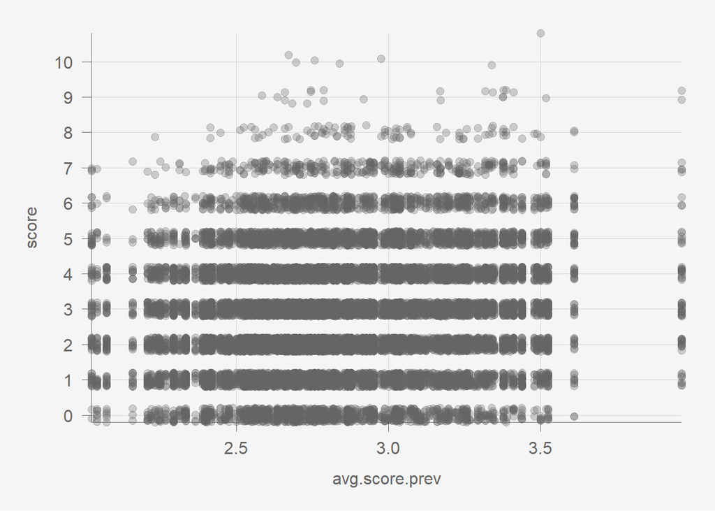

```r
g = ggplot(dh,
           aes(x = avg.score.prev,
               y = score))+
  geom_jitter(alpha  = 0.3,
              height = 0.2,
              width  = 0)

g %>%
  pub(type = 'scatter',
      ybreaks = 0:10)
```

Before fitting a model, let’s check that we see the relationships we expect between our predictor and outcome.

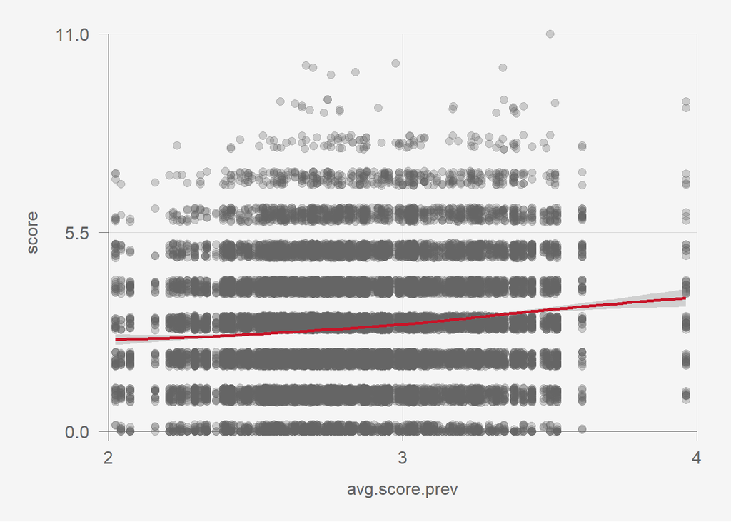

```r
g = ggplot(dh,
           aes(x = avg.score.prev,
               y = score))+
  geom_jitter(alpha  = 0.3,
              height = 0.2,
              width  = 0)+
  geom_smooth(color = pubred)

g %>%
  pub(type = 'scatter',
      ylim = c(0,11),
      xlim = c(2, 4))
```

Let’s take a look at the distribution of `score` for different subsets of our predictor. It should look roughly Poisson, and it should look different for different values of $lambda$. We can bin our data using the function `cut_interval`.

```r
dh = dh %>%
  mutate(bin = cut_interval(avg.score.prev,
                            length = 0.25))
head(dh)
```

```
##         date team score opp opp.score season        gid   ha prev.season
## 1 2013-01-19  PIT     3 BUF         1   2013 2012020001 away        2012
## 2 2013-01-19  BUF     1 PIT         3   2013 2012020001 home        2012
## 3 2013-01-19  OTT     4 WPG         1   2013 2012020002 away        2012
## 4 2013-01-19  WPG     1 OTT         4   2013 2012020002 home        2012
## 5 2013-01-19  CHI     5 LAK         2   2013 2012020003 away        2012
## 6 2013-01-19  LAK     2 CHI         5   2013 2012020003 home        2012
##   avg.score.prev        bin
## 1       3.439024 (3.25,3.5]
## 2       2.939024   (2.75,3]
## 3       3.036585   (3,3.25]
## 4       2.743902 (2.5,2.75]
## 5       3.024390   (3,3.25]
## 6       2.365854 (2.25,2.5]
```

Let’s plot the distribution of score separately for every bin.

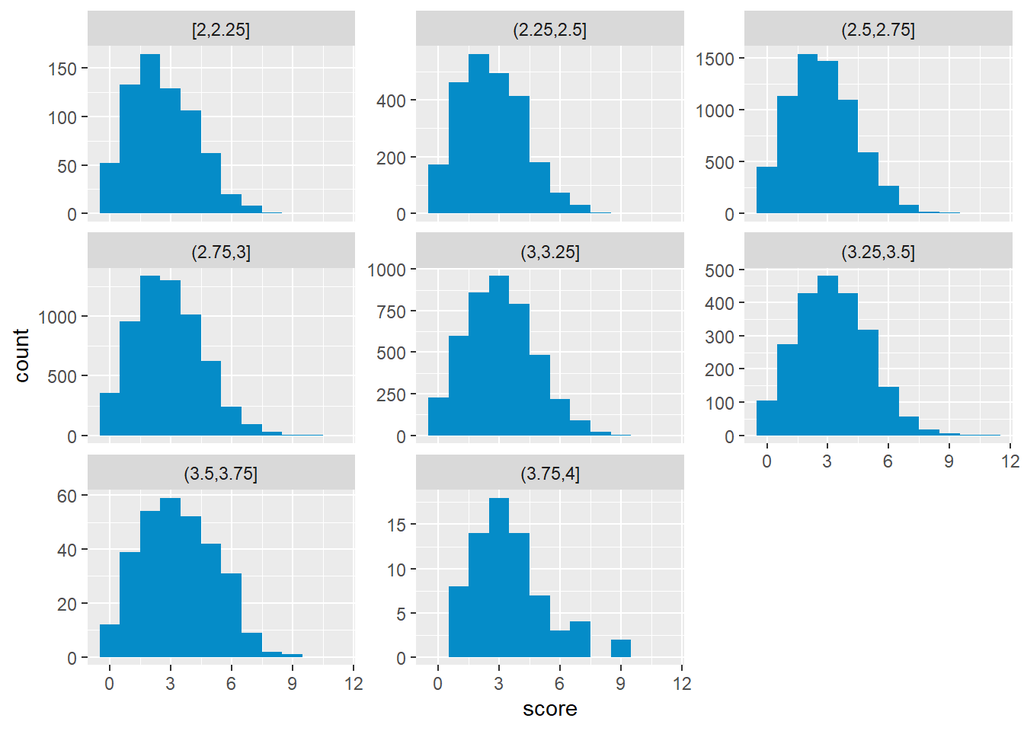

```r
ggplot(data = dh,
       aes(x = score))+
  geom_histogram(binwidth = 1)+
  facet_wrap(~bin,
             scales='free_y')
```

Hmm, it would be nice to have a vertical line showing the mean for every bin.

```r
bin.means = dh %>%
  group_by(bin) %>%
  summarise(mean.score = mean(score),
            var.score = var(score),
            n = n())
bin.means
```

```
## # A tibble: 8 × 4
##   bin        mean.score var.score     n
##   <fct>           <dbl>     <dbl> <int>
## 1 [2,2.25]         2.62      2.60   675
## 2 (2.25,2.5]       2.63      2.51  2393
## 3 (2.5,2.75]       2.76      2.66  6643
## 4 (2.75,3]         2.87      2.77  5969
## 5 (3,3.25]         3.03      2.82  4250
## 6 (3.25,3.5]       3.26      3.11  2259
## 7 (3.5,3.75]       3.38      3.35   301
## 8 (3.75,4]         3.5       3.38    70
```

Let’s plot our histograms with the vertical lines.

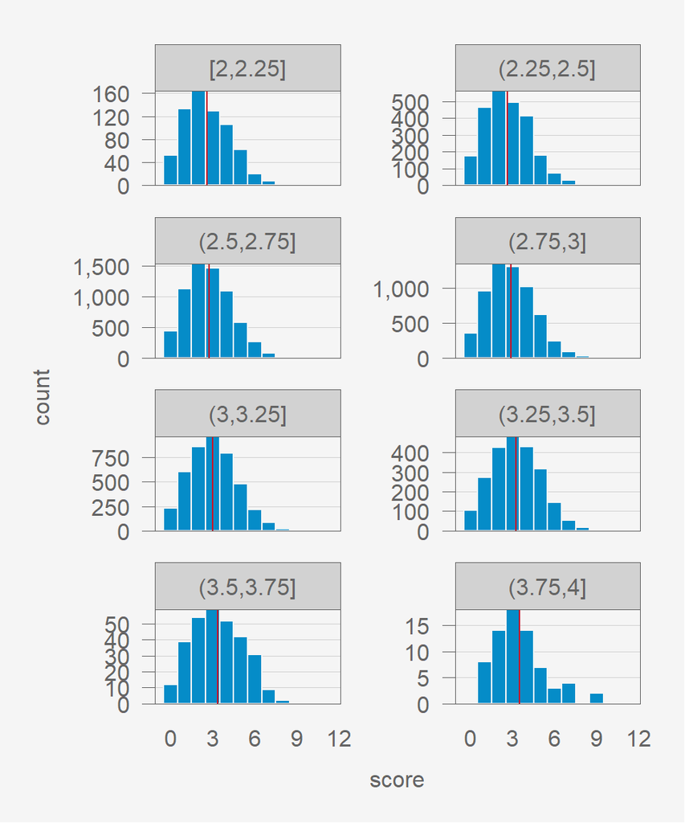

```r
g = ggplot(data = dh,
           aes(x = score)) +
  geom_histogram(binwidth = 1,
                 color    = pubbackgray) +
  geom_vline(data = bin.means,
             aes(xintercept = mean.score),
             color = pubred)+
  facet_wrap(~bin,
             ncol = 2,
             scales = 'free_y')

g %>%
  pub(type = 'hist',
      facet = T)
```

## Animating the distribution of `score` for changing subsets

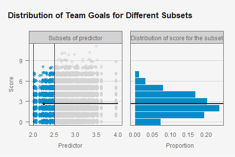

```r
n.frames = length(seq(2.0, 3.75, by=0.1))

## lines
dl = data.frame(left  = seq(2.0, 3.5, length=n.frames),
                right = seq(2.5, 4.00, length=n.frames),
                frame = 1:n.frames) %>%
  mutate(mid = left/2 + right/2)

## Stack two data frames that we want to use
## to plot in two windows
## Give each one NAs so it doesn't show up in the other window
## This is super hack-y, but it avoids making separate animations and
## using magick to glue them together

dl1 = dl %>% mutate(window = 'Subsets of predictor',
                    end = 4.0)
dl2 = dl %>%
  mutate(window = 'Distribution of score for the subset',
         left  = NA,
         right = NA,
         mid   = NA,
         end   = NA)

dl = rbind(dl1, dl2) %>%
  mutate(window = relevel(factor(window),
                          'Subsets of predictor'))


## Gotta manually jitter,
## otherwise the jitter will be different in each frame
dh = dh %>%
  mutate(jitter.score = jitter(score,
                               amount = 0.2))

## data for histogram and highlighted points
ddh = NULL
for(j in  dl$frame){
  left  = dl$left[j]
  right = dl$right[j]
  temp  = dh %>%
    mutate(inside = ifelse(avg.score.prev <= right &
                           avg.score.prev >= left,
                           TRUE,
                           FALSE),
           frame = j)

  ddh = rbind(ddh, temp)
}

## mean of highlighted points
dm = ddh %>%
  filter(inside == TRUE) %>%
  group_by(frame) %>%
  summarise(mean = mean(score),
            var = var(score),
            n = n()) %>%
  as.data.frame()


dl = dl %>%
  left_join(dm,
            by = 'frame')

dl = dl %>%
  mutate(mean.hist = ifelse(window=='Subsets of predictor', NA  , mean),
         mean      = ifelse(window=='Subsets of predictor', mean, NA  ))

ddh2 = ddh %>%
  mutate(hist.score = ifelse(inside == TRUE,
                             score,
                             NA),
         avg.score.prev = NA,
         window = 'Distribution of score for the subset')

ddh$hist.score = NA
ddh$window = 'Subsets of predictor'

ddh = rbind(ddh, ddh2)

ddh = ddh %>%
  mutate(window = relevel(factor(window),
                          'Subsets of predictor'))
#ddh = ddh %>% filter(frame %in% c(1,23))

title = 'Distribution of Team Goals for Different Subsets'
g = ggplot(ddh %>% filter(frame %in% c(1:n.frames)), ## uncomment to test w/ 2 frames
       aes(x = avg.score.prev,
           y = jitter.score,
           color = inside,
           group = gid))+
  geom_point(alpha = 0.3,
             show.legend = F)+
  scale_color_manual(values = c(publightgray,
                                pubblue))+
  geom_vline(data = dl %>% filter(frame %in% c(1:n.frames)),
             aes(xintercept = left),
             color = pubdarkgray)+
  geom_vline(data = dl %>% filter(frame %in% c(1:n.frames)),
             aes(xintercept = right),
             color = pubdarkgray)+
  geom_point(data = dl %>% filter(frame %in% c(1:n.frames)) %>%
               filter(window == 'Subsets of predictor'),
             aes(x = mid,
                 y = mean),
             color = pubdarkgray,
             size = 2,
             inherit.aes = F)+
  geom_segment(data = dl %>% filter(frame %in% c(1:n.frames)),
               aes(x    = mid ,
                   xend = end,
                   y    = mean,
                   yend = mean),
               color = pubdarkgray,
               inherit.aes = F,
               linewidth = 1)+
  geom_histogram(aes(x = after_stat(density),
                     y = hist.score),
                 fill  = pubblue,
                 color = pubbackgray,
                 binwidth = 1,
                 inherit.aes = FALSE)+
  geom_hline(data = dl,
             aes(yintercept = mean.hist),
             color     = pubdarkgray,
             linewidth = 1)+
  facet_wrap(~window,
             scales='free_x')+
  labs(title    = title,
       x = 'Predictor                                                         Proportion',
       y = 'Score')

# g %>%
#   pub(type = 'hist',
#       facet = T)

gg = g %>%
  pub(type = 'hist',
      facet = T) +
  transition_states(states = frame,
                    transition_length = 1,
                    state_length      = 0,
                    wrap = F)
# a = animate(gg,
#             fps     = 10,
#             nframes = 2*n.frames + 14,
#             height  = 320,
#             width   = 480,
#             end_pause = 14)
# a
#
# anim_save(a, filename = 'img/dist.of.score.for.different.subsets.nhl.gif')
```

We can see that for different subsets of our predictor, the distribution of score looks roughly Poisson, and the mean of the distribution (aka $lambda$) increases as the moving window increases and includes larger values of the predictor.

Ok, I think that’s enough data exploration. I think we’ve convinced ourselves that linear regression will be inappropriate and Poisson regression will be appropriate, so let’s fit some models. We’ll start with simple linear regression so we can have something to compare to.

# Regression models for NHL team scores

## Linear Regression with Count Data

If we try a linear regression model to predict NHL game scores, we get reasonable results for the coefficients and predicted game scores.

```r
lm1 = lm(score ~ avg.score.prev,
         data = dh)
summary(lm1)
```

```
##
## Call:
## lm(formula = score ~ avg.score.prev, data = dh)
##
## Residuals:
##    Min     1Q Median     3Q    Max
## -3.357 -1.103 -0.006  1.147  7.710
##
## Coefficients:
##                Estimate Std. Error t value Pr(>|t|)
## (Intercept)     1.15257    0.09828   11.73   <2e-16 ***
## avg.score.prev  0.61056    0.03448   17.71   <2e-16 ***
## ---
## Signif. codes:  0 '***' 0.001 '**' 0.01 '*' 0.05 '.' 0.1 ' ' 1
##
## Residual standard error: 1.66 on 22558 degrees of freedom
## Multiple R-squared:  0.01371,    Adjusted R-squared:  0.01367
## F-statistic: 313.6 on 1 and 22558 DF,  p-value: < 2.2e-16
```

While the coefficients seem reasonable, but since the residuals aren’t normally distributed, many other outputs from `summary()` that depend on that assumption (e.g. Standard Error, p-value) won’t be reliable. Not surprisingly, from what we saw in the histogram of game scores, the residuals appear right-skewed.

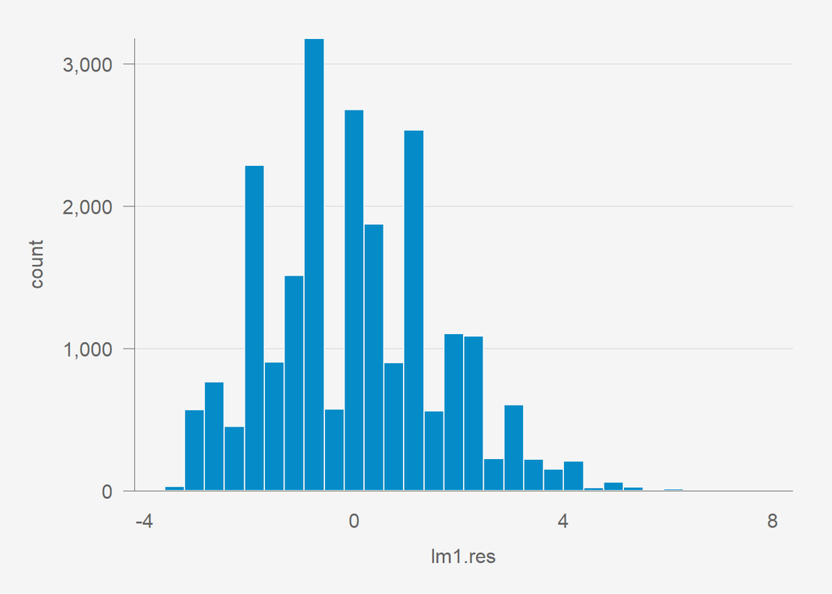

```r
dh$lm1.pred = predict(lm1,
                      newdata = dh)
dh$lm1.res  = dh$score - dh$lm1.pred

g = ggplot(dh,
           aes(x = lm1.res)) +
  geom_histogram(color = pubbackgray)

g %>%
  pub(type = 'hist')
```

## Poisson Regression using `glm`

We can use Poisson regression when out outcome is count data that follows a Poisson distribution. Let’s use Poisson regression for predicting hockey game scores

```r
glm1 = glm(score ~ avg.score.prev,
           data = dh,
           family = 'poisson')
summary(glm1)
```

```
##
## Call:
## glm(formula = score ~ avg.score.prev, family = "poisson", data = dh)
##
## Coefficients:
##                Estimate Std. Error z value Pr(>|z|)
## (Intercept)     0.46091    0.03487   13.22   <2e-16 ***
## avg.score.prev  0.21016    0.01214   17.31   <2e-16 ***
## ---
## Signif. codes:  0 '***' 0.001 '**' 0.01 '*' 0.05 '.' 0.1 ' ' 1
##
## (Dispersion parameter for poisson family taken to be 1)
##
##     Null deviance: 24796  on 22559  degrees of freedom
## Residual deviance: 24498  on 22558  degrees of freedom
## AIC: 85707
##
## Number of Fisher Scoring iterations: 5
```

## Coefficients, linear vs Poisson

The coefficients in these two models are different.

```r
coefs = rbind(data.frame(summary( lm1)$coefficients[,1:2], model='Linear'),
              data.frame(summary(glm1)$coefficients[,1:2], model='Poisson')) %>%
  mutate(varname = rep(c('(Intercept)', 'avg.score.prev'),2)) %>%
  rename(est = Estimate,
         se  = Std..Error) %>%
  arrange(varname) %>%
  remove_rownames() %>%
  select(varname, model, est, se)
coefs
```

```
##          varname   model       est         se
## 1    (Intercept)  Linear 1.1525732 0.09828279
## 2    (Intercept) Poisson 0.4609066 0.03486786
## 3 avg.score.prev  Linear 0.6105562 0.03447671
## 4 avg.score.prev Poisson 0.2101633 0.01213801
```

Note that Poisson is a multiplicative model and the coefficients have a different interpretation from the linear regression coefficients.

## Predicted scores, linear vs Poisson

Let’s check the predicted scores for these models.

```r
dh$glm1.pred = predict(glm1,
                       newdata = dh,
                       type = 'response')
dh$res   = dh$glm1.pred - dh$score
dh$diff1 = dh$glm1.pred - dh$lm1.pred
dh %>%
  select(score, lm1.pred, glm1.pred, diff1) %>%
  tail()
```

```
##       score lm1.pred glm1.pred        diff1
## 22555     1 3.300423  3.320884  0.020461457
## 22556     4 3.125978  3.127345  0.001366936
## 22557     1 2.853408  2.847273 -0.006135879
## 22558     3 3.006047  3.000870 -0.005177144
## 22559     4 2.853408  2.847273 -0.006135879
## 22560     5 2.820700  2.815396 -0.005304450
```

```r
mean(abs(dh$diff1),
     na.rm = T)
```

```
## [1] 0.006177345
```

Note that without `type='response'`, the `predict` code above would give predictions on the `log` scale.

## Plotting the predictions

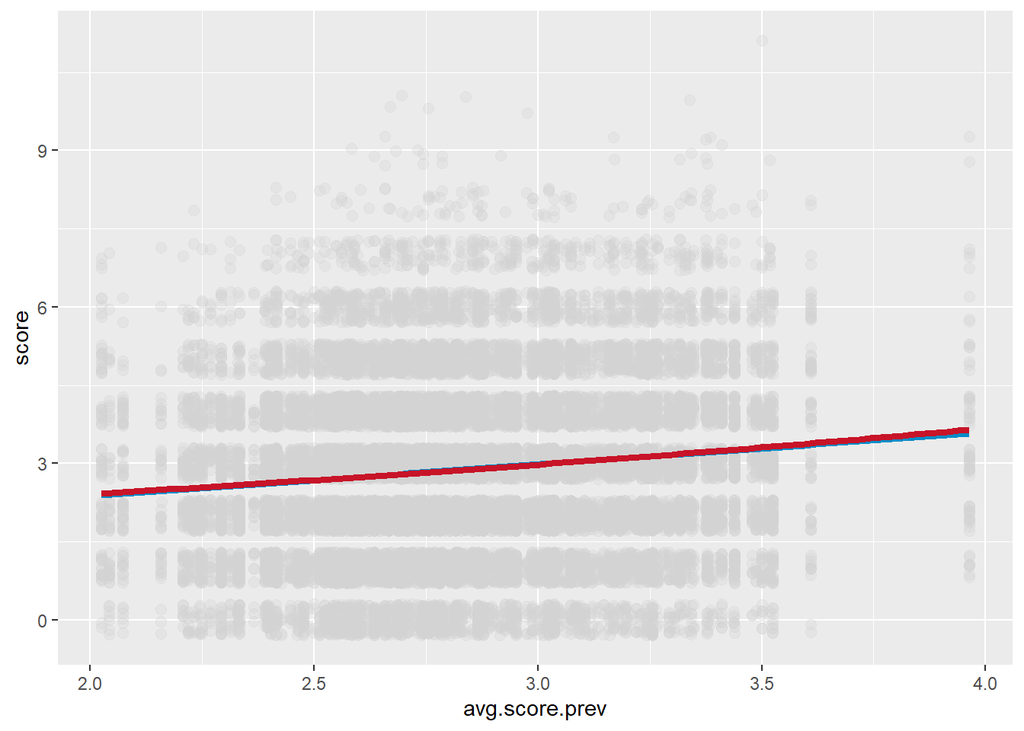

```r
ggplot(dh,
       aes(x = avg.score.prev,
           y = score))+
  geom_jitter(alpha  = 0.3,
              height = 0.3,
              color  = publightgray)+
  geom_smooth(method = 'lm' ,
              color  = pubblue,
              linewidth = 1.5,
              se = F) +
  geom_smooth(method = 'glm',
              color  = pubred,
              linewidth = 1.5,
              se = F,
              method.args = list(family='poisson'))
```

In this case, the lines are pretty close, though the Poisson regression curve is more, well, curved. And again, it’s not all about the prediction of the mean value in this example. They are pretty close. It’s about the uncertainties, and the distribution of `score` for a given value of the predictor.

## Confidence intervals for the coefficients

```r
confint(lm1)
```

```
##                    2.5 %    97.5 %
## (Intercept)    0.9599322 1.3452143
## avg.score.prev 0.5429795 0.6781329
```

```r
confint(glm1)
```

```
##                    2.5 %    97.5 %
## (Intercept)    0.3925570 0.5292366
## avg.score.prev 0.1863663 0.2339465
```

```r
exp(confint(glm1))
```

```
##                   2.5 %   97.5 %
## (Intercept)    1.480762 1.697636
## avg.score.prev 1.204864 1.263577
```

```r
summary(glm1)$coefficients[2,1] - qnorm(.975, 0, 1)*summary(glm1)$coefficients[2,2]
```

```
## [1] 0.1863732
```

```r
summary(glm1)$coefficients[2,1] + qnorm(.975, 0, 1)*summary(glm1)$coefficients[2,2]
```

```
## [1] 0.2339534
```

## Confidence intervals for predictions

```r
predict(lm1  , newdata=dh, interval='confidence', level=.95) %>% tail()
```

```
##            fit      lwr      upr
## 22555 3.300423 3.249301 3.351545
## 22556 3.125978 3.091364 3.160592
## 22557 2.853408 2.831516 2.875301
## 22558 3.006047 2.980404 3.031691
## 22559 2.853408 2.831516 2.875301
## 22560 2.820700 2.797999 2.843401
```

```r
predict(glm1 , newdata=dh, interval='confidence', level=.95, type='response') %>% tail()
```

```
##    22555    22556    22557    22558    22559    22560
## 3.320884 3.127345 2.847273 3.000870 2.847273 2.815396
```

Hmm, that’s not the expected output for our glm. We’ll deal with that later.

**find pred and se.fit for ‘link’ then exp(), or find pred and se.fit for ‘response’? Can skip this for now.**

```r
n = nrow(dh)
sse = sum(dh$res^2)
s2 = sse/(n-2)

sxx = sum((dh$score - mean(dh$score))^2)
s2beta1hat = s2/sxx
s2beta1hat
```

```
## [1] 4.371401e-05
```

```r
sbeta1hat = sqrt(s2beta1hat)
sbeta1hat
```

```
## [1] 0.006611657
```

```r
xstar = dh$avg.score.prev[1]
yhat = d$pred1[1]
s2yhat = s2*(1/n + (xstar - mean(d$log.living))^2/sxx) ## ugh
syhat = sqrt(s2yhat)
syhat
```

```
## [1] NA
```

```r
predict( lm1,  newdata=dh, interval='confidence', level=0.95) %>% head()
```

```
##        fit      lwr      upr
## 1 3.252291 3.205939 3.298643
## 2 2.947013 2.924189 2.969837
## 3 3.006579 2.980904 3.032254
## 4 2.827880 2.805404 2.850356
## 5 2.999133 2.973891 3.024376
## 6 2.597060 2.558795 2.635324
```

```r
dh$glm1.link = predict(glm1,  newdata=dh, type='link', se.fit=T)$fit
dh$glm.se.response = predict(glm1,  newdata=dh, type='response', se.fit=T)$se.fit
dh$glm.se.link     = predict(glm1,  newdata=dh, type='link'    , se.fit=T)$se.fit
dh$glm.lambda.lower.response =  dh$glm1.pred - qnorm(.975, 0, 1)*dh$glm.se.response
dh$glm.lambda.lower.link     = (dh$glm1.link - qnorm(.975, 0, 1)*dh$glm.se.link) %>% exp()
dh$glm.lambda.upper.response =  dh$glm1.pred + qnorm(.975, 0, 1)*dh$glm.se.response
dh$glm.lambda.upper.link     = (dh$glm1.link + qnorm(.975, 0, 1)*dh$glm.se.link) %>% exp()
dh %>%
  select(score, glm1.pred, glm.se.response, glm.se.link,
         glm.lambda.lower.response, glm.lambda.lower.link,
         glm.lambda.upper.response, glm.lambda.upper.link) %>%
  tail()
```

```
##       score glm1.pred glm.se.response glm.se.link glm.lambda.lower.response
## 22555     1  3.320884      0.02974625 0.008957329                  3.262583
## 22556     4  3.127345      0.01886904 0.006033566                  3.090362
## 22557     1  2.847273      0.01141574 0.004009362                  2.824898
## 22558     3  3.000870      0.01349530 0.004497129                  2.974420
## 22559     4  2.847273      0.01141574 0.004009362                  2.824898
## 22560     5  2.815396      0.01180517 0.004193075                  2.792258
##       glm.lambda.lower.link glm.lambda.upper.response glm.lambda.upper.link
## 22555              3.263091                  3.379186              3.379701
## 22556              3.090580                  3.164328              3.164547
## 22557              2.824986                  2.869647              2.869735
## 22558              2.974536                  3.027321              3.027438
## 22559              2.824986                  2.869647              2.869735
## 22560              2.792353                  2.838533              2.838629
```

## Plotting confidence intervals for predictions

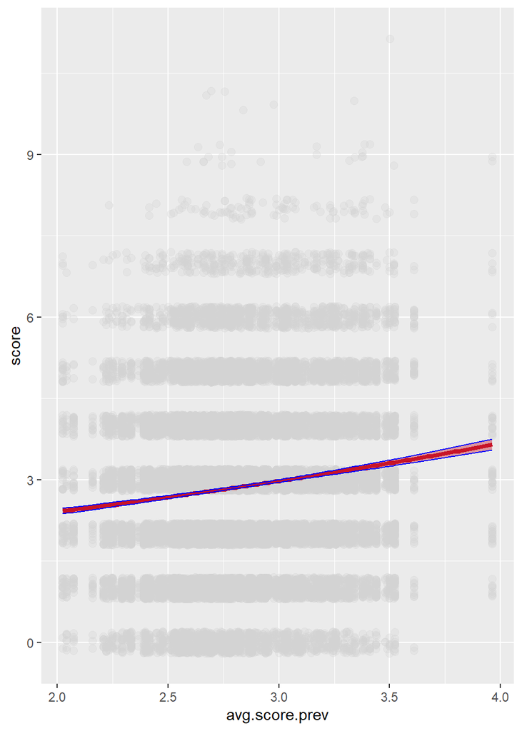

```r
ggplot(dh,
       aes(x = avg.score.prev,
           y = score))+
  geom_jitter(alpha = 0.3,
              height = 0.2,
              color = publightgray)+
  geom_smooth(method = 'glm',
              color = pubred,
              fill = pubred,
              linewidth = 1.5,
              se=T,
              method.args = list(family='poisson'))+
  geom_line(aes(x=avg.score.prev, y=glm.lambda.lower.response), linewidth=0.5, color='red')+
  geom_line(aes(x=avg.score.prev, y=glm.lambda.upper.response), linewidth=0.5, color='red')+
  geom_line(aes(x=avg.score.prev, y=glm.lambda.lower.link), linewidth=0.5, color='blue')+
  geom_line(aes(x=avg.score.prev, y=glm.lambda.upper.link), linewidth=0.5, color='blue')
```

```r
  #ylim(c(3,5))
```

## Interpretation of the coefficients

Let’s verify the interpretation of the coefficients for the Poisson regression model.

```r
df = data.frame(avg.score.prev = seq(0, 5.0, by=1))

df = df %>%
  mutate(pred  = predict(glm1, newdata=df, type='response'),
         ratio = pred/lag(pred),
         link  = predict(glm1, newdata=df, type='link'),
         diff  = link - lag(link))
df
```

```
##   avg.score.prev     pred   ratio      link      diff
## 1              0 1.585511      NA 0.4609066        NA
## 2              1 1.956329 1.23388 0.6710699 0.2101633
## 3              2 2.413875 1.23388 0.8812332 0.2101633
## 4              3 2.978431 1.23388 1.0913965 0.2101633
## 5              4 3.675025 1.23388 1.3015598 0.2101633
## 6              5 4.534538 1.23388 1.5117231 0.2101633
```

```r
df$ratio
```

```
##       1       2       3       4       5       6
##      NA 1.23388 1.23388 1.23388 1.23388 1.23388
```

```r
df$diff
```

```
##         1         2         3         4         5         6
##        NA 0.2101633 0.2101633 0.2101633 0.2101633 0.2101633
```

```r
glm1$coefficients['avg.score.prev'] %>% exp()
```

```
## avg.score.prev
##        1.23388
```

```r
glm1$coefficients['avg.score.prev']
```

```
## avg.score.prev
##      0.2101633
```

## Multiple regression models for NHL team scores

Let’s build models with `ha`, `team`, and `opp`, like we did with basketball. We’ll do both linear and Poisson regression again.

**Do this for only the most recent season.**

```r
dh = dh %>% filter(season == 2022)
lm2  =  lm(score ~ ha + team + opp, data=dh)
glm2 = glm(score ~ ha + team + opp, data=dh, family='poisson')
```

Coefficients are highly correlated with linear regression estimates.

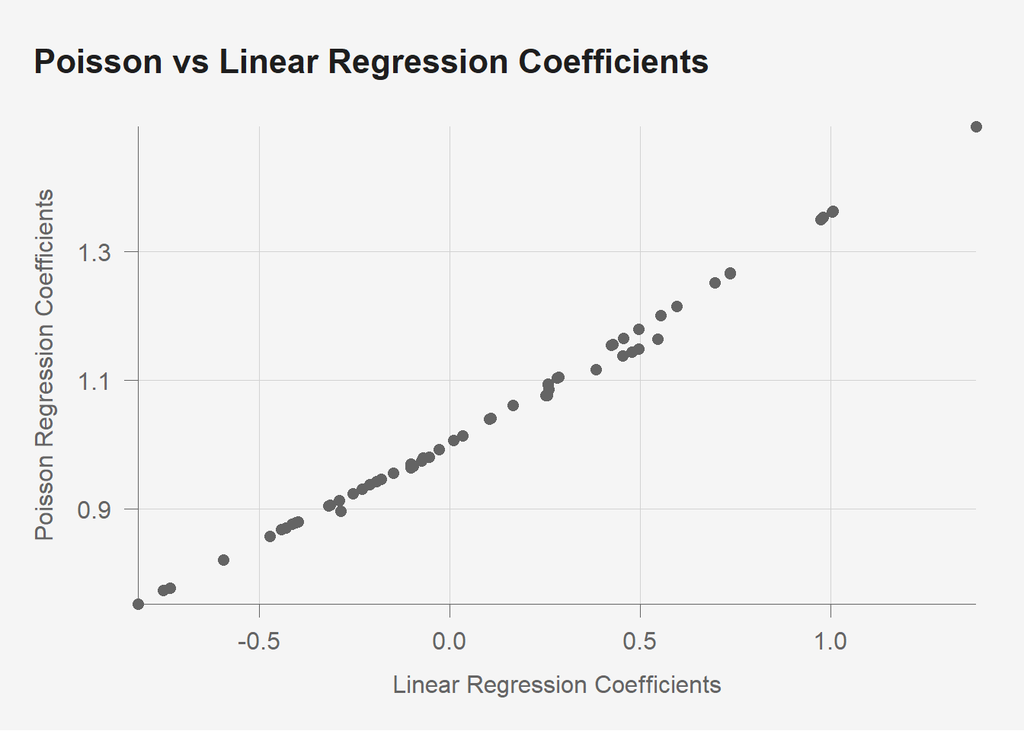

```r
dg = data.frame(lm = lm2$coefficients[-1],
                glm = exp(glm2$coefficients[-1]))
title = "Poisson vs Linear Regression Coefficients"
g = ggplot(dg,
           aes(x = lm,
               y = glm))+
  geom_point()+
  labs(title    = title,
       x = 'Linear Regression Coefficients',
       y = 'Poisson Regression Coefficients')


g %>%
  pub(type = 'scatter')
```

So we get similar team ratings (or, at least the order is about the same). We also get similar predictions

```r
dh$lm2  = predict(lm2, newdata=dh)
dh$glm2 = predict(glm2, newdata=dh, type='response') ## with
dh$diff2 = dh$lm2 - dh$glm2
mean(abs(dh$diff2))
```

```
## [1] 0.03712303
```

```r
head(dh)
```

```
##         date team score opp opp.score season        gid   ha prev.season
## 1 2021-10-12  PIT     6 TBL         2   2022 2021020001 away        2021
## 2 2021-10-12  TBL     2 PIT         6   2022 2021020001 home        2021
## 3 2021-10-13  MTL     1 TOR         2   2022 2021020003 away        2021
## 4 2021-10-13  TOR     2 MTL         1   2022 2021020003 home        2021
## 5 2021-10-13  NYR     1 WSH         5   2022 2021020004 away        2021
## 6 2021-10-13  WSH     5 NYR         1   2022 2021020004 home        2021
##   avg.score.prev        bin jitter.score lm1.pred   lm1.res glm1.pred       res
## 1       3.500000 (3.25,3.5]    5.9794197 3.289520  2.710480  3.308445 -2.691555
## 2       3.232143   (3,3.25]    1.8446113 3.125978 -1.125978  3.127345  1.127345
## 3       2.839286   (2.75,3]    1.0651529 2.886117 -1.886117  2.879510  1.879510
## 4       3.339286 (3.25,3.5]    1.9621275 3.191395 -1.191395  3.198564  1.198564
## 5       3.160714   (3,3.25]    0.9786614 3.082367 -2.082367  3.080749  2.080749
## 6       3.410714 (3.25,3.5]    4.9636604 3.235006  1.764994  3.246942 -1.753058
##          diff1 glm1.link glm.se.response glm.se.link glm.lambda.lower.response
```

[output cut: 20 more lines]

While the coefficients and the predicted scores are very similar for linear and Poisson regression, the assumptions for Poisson regression are much more closely met since our outcome is count data, so other outputs like standard error are more reliable.

## Poisson Regression Assumptions

**Done on board.**

Review linear regression assumptions.

$y \sim N(\mu, \sigma^2)$, where $\mu = \beta_0 + \beta_1 x$

Poisson regression assumptions: